# Analysis of Alpha and Beta diversity in R - rarefaction, alpha- and beta- diversity and vizualizations Venkataraman_2016_V4_forward_only-potato

### Packages needed:

```r
require(vegan)
```

```r
require(ggplot2)
require(data.table)
require(anchors)
require(EcolUtils)
require(car)
require(tidyverse)
require(dplyr)
require(rstatix)
library("extrafont")
```

### Set working directory:

```r
setwd("/Volumes/Seagate/Meta_analysis/Alpha_Beta_analysis/Venkataraman_2016_V4/Potato/")
```

## __________ Documents needed: __________

- 1. *SV.table* - **filtered_forward_phylum_feature-table_modified_header.tsv** is the operational taxonomic unit table (OTU table) that was obtained after DADA2 and underwent curation by clearing mitochondrial and chloroplast DNA and only keeping OTUs that were assigned to the phylum level named. The header was modified to remove “Constructed from biom file” line and changed “OTU ID” to OTUID"
- 2. *Metadata* - **venkataraman_metadata_potato.txt** is the Metadata file containing the description of each sample.

*The files chosen are from the processing of the forward single end reads.

## __________ Read in your data _________

#### Import metadata:

```r
setwd("/Volumes/Seagate/Meta_analysis/Alpha_Beta_analysis/Venkataraman_2016_V4/Input_files")

metadata <- as.data.frame(fread("1.venkataraman_metadata.tsv"))

str(metadata)
```

```
#> 'data.frame':    157 obs. of  17 variables:
#>  $ sampleid            : chr  "SRR3053238_venkataraman" "SRR3053239_venkataraman" "SRR3053240_venkataraman" "SRR3053241_venkataraman" ...
#>  $ study               : chr  "venkataraman" "venkataraman" "venkataraman" "venkataraman" ...
#>  $ sample_id_2         : chr  "SRR3053238" "SRR3053239" "SRR3053240" "SRR3053241" ...
#>  $ subject_id          : chr  "venkataraman_U001" "venkataraman_U001" "venkataraman_U001" "venkataraman_U001" ...
#>  $ treatment           : chr  "fiber" "fiber" "fiber" "fiber" ...
#>  $ timepoint           : chr  "before" "before" "before" "before" ...
#>  $ timepoint_numeric   : int  1 2 3 4 5 6 7 8 1 2 ...
#>  $ timepoint_id        : chr  "before_1" "before_2" "before_3" "before_4" ...
#>  $ sample_name1        : chr  "venkataraman_U001_1" "venkataraman_U001_2" "venkataraman_U001_3" "venkataraman_U001_4" ...
#>  $ fiber_type          : chr  "potato_starch" "potato_starch" "potato_starch" "potato_starch" ...
#>  $ fiber_amount        : chr  "48g" "48g" "48g" "48g" ...
#>  $ time_days           : chr  "1d" "3d" "5d" "7d" ...
#>  $ number              : int  1 2 3 4 5 6 7 8 9 10 ...
#>  $ gender              : logi  NA NA NA NA NA NA ...
#>  $ age                 : logi  NA NA NA NA NA NA ...
#>  $ sample-name-original: chr  "U001_1" "U001_2" "U001_3" "U001_4" ...
#>  $ subject_id2         : chr  "U001" "U001" "U001" "U001" ...
```

##### In metadata file, set subject-id, timepoint as factors: There are a number of advantages to converting categorical variables to factor variables. For instance, they can be used in statistical modeling where they will be implemented correctly, i.e., they will then be assigned the correct number of degrees of freedom

```r
metadata <- metadata %>%
  convert_as_factor(`timepoint`)

metadata <- metadata %>%
  convert_as_factor(`subject_id`)

metadata <- metadata %>%
  convert_as_factor(`subject_id2`)

metadata <- metadata %>%
  convert_as_factor(`sampleid`)

#Confirm variables have been changed to factors:
class(metadata$`timepoint`)
```

```
#> [1] "factor"
```

```r
class(metadata$`subject_id`)
```

```
#> [1] "factor"
```

```r
class(metadata$`subject_id2`)
```

```
#> [1] "factor"
```

```r
class(metadata$`sampleid`)
```

```
#> [1] "factor"
```

#### Read in SV table with all data no need to subset samples in potato treatment only based on metadata since that is the only fiber treatment:

```r
setwd("/Volumes/Seagate/Meta_analysis/Alpha_Beta_analysis/Venkataraman_2016_V4/Input_files")

SV.table <- as.data.frame(fread("1.filtered_forward_phylum_feature-table_modified_header.tsv", header = TRUE))

#Set OTUID as the row names:
row.names(SV.table) <- SV.table$`#OTUID`
SV.table <- SV.table[ , !(names(SV.table) %in% c("#OTUID"))]
```

#### Save the subsetted data (for this study same as raw data since we did not have to subset samples per fiber):

```r
setwd("/Volumes/Seagate/Meta_analysis/Alpha_Beta_analysis/Venkataraman_2016_V4/Potato/Output_files")

#Save subset of samples in a file:
write.table(SV.table, file = "1.SV.table_fiber.tsv", sep = "\t", row.names = TRUE, col.names = NA)
```

## __________ Rarefy your data _________

#### Transform the dataframes because vegan expects rows = samples and columns = species:

```r
SV.table <- as.data.frame(t(SV.table))
```

#### Look at the first few rows and columns to ensure data got transposed:

```r
SV.table[1:5,1:5]
```

```
#>            87cc06884cf6622966eb4fc785561d54 ce7b38de22a3c940c219b18fb1db32e3
#> SRR3053238                                0                                0
#> SRR3053239                                0                                0
#> SRR3053240                                0                                0
#> SRR3053241                                0                                0
#> SRR3053242                                0                                0
#>            3eca1aeb6b6ddfac84c7cbe73a97d9a4 ea0dc229a54bb478c4eb058f08fbad25
#> SRR3053238                                0                                0
#> SRR3053239                                0                                0
#> SRR3053240                                0                                0
#> SRR3053241                                0                                0
#> SRR3053242                                0                                0
#>            67eac209bac9a0cc7d8136d08a8f8e3a
#> SRR3053238                                0
#> SRR3053239                                0
#> SRR3053240                                0
#> SRR3053241                                0
#> SRR3053242                                0
```

#### See the total number of samples and SVs, by looking at the dimensions of the table:

```r
dim(SV.table)
```

```
#> [1]  157 3560
```

##### Results:

R always uses rows, then columns. So in this case we have and 157 samples and 3560 SVs.

#### If we now want to know the total number of reads we have we can just count up the total of the SVs sum in table:

```r
sum(SV.table)
```

```
#> [1] 4566446
```

##### Results:

We have 4566446 reads.

#### To see the number of reads per sample, we simply need to add up the rows on the file:

```r
reads.per.sample <- rowSums(SV.table) %>% sort()
reads.per.sample
```

```
#> SRR3053279 SRR3053459 SRR3053281 SRR3053511 SRR3053273 SRR3053272 SRR3053345
#>       2167       4797       7154       9103       9836      11185      14327
#> SRR3053380 SRR3053335 SRR3053288 SRR3053283 SRR3053260 SRR3053311 SRR3053274
#>      15862      15893      16431      16457      16787      17112      17167
#> SRR3053267 SRR3053282 SRR3053312 SRR3053285 SRR3053535 SRR3053543 SRR3053239
#>      17597      17789      17817      17878      18215      18765      19161
#> SRR3053270 SRR3053271 SRR3053386 SRR3053243 SRR3053316 SRR3053248 SRR3053541
#>      20270      20372      20515      20992      21057      21285      21307
#> SRR3053276 SRR3053317 SRR3053347 SRR3053277 SRR3053357 SRR3053360 SRR3053322
#>      21410      21551      21748      21887      21902      21943      21945
#> SRR3053354 SRR3053255 SRR3053352 SRR3053355 SRR3053391 SRR3053314 SRR3053332
#>      22116      22302      22625      22655      22792      23352      23845
#> SRR3053362 SRR3053460 SRR3053252 SRR3053258 SRR3053302 SRR3053292 SRR3053542
#>      23873      24013      24208      24529      24839      24858      25031
#> SRR3053310 SRR3053304 SRR3053544 SRR3053253 SRR3053538 SRR3053333 SRR3053458
#>      25155      25219      25388      25531      25650      25904      25930
#> SRR3053299 SRR3053293 SRR3053339 SRR3053388 SRR3053319 SRR3053348 SRR3053340
#>      26052      26830      26831      27086      27240      27317      27326
#> SRR3053261 SRR3053361 SRR3053540 SRR3053241 SRR3053329 SRR3053356 SRR3053286
#>      27741      27760      27933      28021      28100      28464      28472
#> SRR3053240 SRR3053488 SRR3053323 SRR3053262 SRR3053324 SRR3053306 SRR3053254
#>      28520      28529      28682      28725      29304      29372      29498
#> SRR3053326 SRR3053337 SRR3053264 SRR3053266 SRR3053336 SRR3053390 SRR3053245
#>      29545      29836      29881      29942      30060      30274      30407
#> SRR3053313 SRR3053343 SRR3053393 SRR3053320 SRR3053358 SRR3053309 SRR3053321
#>      30597      30676      30935      31079      31090      31196      31408
#> SRR3053269 SRR3053536 SRR3053539 SRR3053287 SRR3053265 SRR3053462 SRR3053308
#>      31751      31845      31871      31883      31925      32093      32221
#> SRR3053334 SRR3053280 SRR3053353 SRR3053275 SRR3053537 SRR3053242 SRR3053315
#>      32344      32393      32472      32484      32568      32569      32734
#> SRR3053307 SRR3053251 SRR3053346 SRR3053284 SRR3053461 SRR3053318 SRR3053238
#>      33200      33268      33437      33464      33594      33805      33945
#> SRR3053256 SRR3053296 SRR3053463 SRR3053387 SRR3053259 SRR3053297 SRR3053290
#>      33953      33978      34064      34619      34655      35008      35231
#> SRR3053278 SRR3053244 SRR3053349 SRR3053250 SRR3053338 SRR3053328 SRR3053257
#>      35539      35748      35821      36050      36057      36281      36440
#> SRR3053410 SRR3053434 SRR3053303 SRR3053342 SRR3053389 SRR3053512 SRR3053298
#>      36565      36668      36927      37145      37183      37380      37461
#> SRR3053392 SRR3053305 SRR3053268 SRR3053295 SRR3053350 SRR3053294 SRR3053246
#>      37876      38238      38477      38531      38599      38695      39346
#> SRR3053489 SRR3053291 SRR3053300 SRR3053330 SRR3053341 SRR3053351 SRR3053359
#>      39416      39498      39668      39892      40248      41224      41974
#> SRR3053301 SRR3053263 SRR3053327 SRR3053411 SRR3053325 SRR3053331 SRR3053344
#>      42194      42452      43038      43559      44998      45035      46446
#> SRR3053249 SRR3053289 SRR3053247
#>      47024      48447      48704
```

```r
#Save a file with the information of reads per sample:
setwd("/Volumes/Seagate/Meta_analysis/Alpha_Beta_analysis/Venkataraman_2016_V4/Potato/Output_files")
write.table(reads.per.sample, file = "2.reads.per.sample.tsv", sep = "\t", row.names = TRUE, col.names = NA)
```

#### To see the max. & min. number of reads and how frequently certain features (SVs) are found, add up the rows and col:

```r
rowSums(SV.table) %>% summary()
```

```
#>    Min. 1st Qu.  Median    Mean 3rd Qu.    Max.
#>    2167   22792   29836   29086   35008   48704
```

```r
colSums(SV.table) %>% summary()
```

```
#>    Min. 1st Qu.  Median    Mean 3rd Qu.    Max.
#>       2       3       5    1283      39  638470
```

#### Result:

- The min. number of sequences in a sample are 2167 and the max. is 48704; we can use 2167 for rarefaction depth.
- The min. value for the presence of an SV is 2 and the max. times an SV is present is 638470.

#### Performing the actual rarefaction

- Rarefaction depth should be >= 1000 at least, we will use the minimum value of sequence depth which is 2167
- Round out the averages, so we will not have exactly 2167 sequences in each, but we also will not be keeping the super rare, super low abundance << 1 taxa https://rdrr.io/github/GuillemSalazar/EcolUtils/man/rrarefy.perm.html

```r
set.seed(2022) #reproducible results
SV.table.rarefied <- as.data.frame((rrarefy.perm(SV.table, sample = 2167, n = 1000, round.out = TRUE)))
```

#### To check that the rarefaction worked out check the number of reads per sample:

```r
sort(rowSums(SV.table.rarefied))
```

```
#> SRR3053257 SRR3053240 SRR3053303 SRR3053331 SRR3053239 SRR3053249 SRR3053290
#>       2149       2152       2152       2152       2153       2153       2153
#> SRR3053359 SRR3053242 SRR3053250 SRR3053287 SRR3053309 SRR3053319 SRR3053324
#>       2154       2155       2155       2155       2155       2155       2155
#> SRR3053265 SRR3053280 SRR3053310 SRR3053311 SRR3053332 SRR3053244 SRR3053246
#>       2156       2156       2156       2156       2156       2157       2157
#> SRR3053269 SRR3053337 SRR3053241 SRR3053245 SRR3053256 SRR3053291 SRR3053306
#>       2157       2157       2158       2158       2158       2158       2158
#> SRR3053352 SRR3053460 SRR3053463 SRR3053247 SRR3053251 SRR3053264 SRR3053295
#>       2158       2158       2158       2159       2159       2159       2159
#> SRR3053299 SRR3053308 SRR3053318 SRR3053321 SRR3053322 SRR3053328 SRR3053344
#>       2159       2159       2159       2159       2159       2159       2159
#> SRR3053357 SRR3053410 SRR3053259 SRR3053278 SRR3053286 SRR3053294 SRR3053325
#>       2159       2159       2160       2160       2160       2160       2160
#> SRR3053343 SRR3053360 SRR3053362 SRR3053386 SRR3053390 SRR3053393 SRR3053434
#>       2160       2160       2160       2160       2160       2160       2160
#> SRR3053458 SRR3053461 SRR3053260 SRR3053275 SRR3053296 SRR3053297 SRR3053302
#>       2160       2160       2161       2161       2161       2161       2161
#> SRR3053304 SRR3053336 SRR3053339 SRR3053351 SRR3053537 SRR3053543 SRR3053253
#>       2161       2161       2161       2161       2161       2161       2162
#> SRR3053254 SRR3053268 SRR3053274 SRR3053277 SRR3053282 SRR3053292 SRR3053298
#>       2162       2162       2162       2162       2162       2162       2162
#> SRR3053312 SRR3053314 SRR3053330 SRR3053341 SRR3053350 SRR3053355 SRR3053356
#>       2162       2162       2162       2162       2162       2162       2162
#> SRR3053380 SRR3053411 SRR3053459 SRR3053238 SRR3053252 SRR3053263 SRR3053281
#>       2162       2162       2162       2163       2163       2163       2163
#> SRR3053284 SRR3053300 SRR3053307 SRR3053313 SRR3053316 SRR3053320 SRR3053326
#>       2163       2163       2163       2163       2163       2163       2163
#> SRR3053342 SRR3053345 SRR3053358 SRR3053389 SRR3053391 SRR3053392 SRR3053462
#>       2163       2163       2163       2163       2163       2163       2163
#> SRR3053488 SRR3053540 SRR3053261 SRR3053266 SRR3053270 SRR3053271 SRR3053285
#>       2163       2163       2164       2164       2164       2164       2164
#> SRR3053346 SRR3053348 SRR3053387 SRR3053512 SRR3053539 SRR3053544 SRR3053255
#>       2164       2164       2164       2164       2164       2164       2165
#> SRR3053276 SRR3053288 SRR3053289 SRR3053293 SRR3053301 SRR3053317 SRR3053323
#>       2165       2165       2165       2165       2165       2165       2165
#> SRR3053334 SRR3053349 SRR3053361 SRR3053542 SRR3053262 SRR3053305 SRR3053329
#>       2165       2165       2165       2165       2166       2166       2166
#> SRR3053535 SRR3053536 SRR3053538 SRR3053267 SRR3053272 SRR3053279 SRR3053283
#>       2166       2166       2166       2167       2167       2167       2167
#> SRR3053315 SRR3053340 SRR3053353 SRR3053354 SRR3053489 SRR3053511 SRR3053248
#>       2167       2167       2167       2167       2167       2167       2168
#> SRR3053273 SRR3053333 SRR3053335 SRR3053388 SRR3053541 SRR3053243 SRR3053258
#>       2168       2168       2168       2168       2168       2169       2169
#> SRR3053327 SRR3053338 SRR3053347
#>       2170       2171       2172
```

#### Results:

We obtained roughly the same number of reads per sample.

#### Save filtered & rarefied OTU SV.table.rarefied:

```r
setwd("/Volumes/Seagate/Meta_analysis/Alpha_Beta_analysis/Venkataraman_2016_V4/Potato/Output_files")

write.table(SV.table.rarefied, file = "3.potato_OTU_filtered_rarefied_2167_ROUNDED.tsv", sep = "\t", row.names = TRUE, col.names = NA)
```

## __________ Alpha-diversity Analyses_________

#### Calculate different alpha diversity metrics (Shannon, Richness, Simpson):

```r
shannon <- as.data.frame(diversity(SV.table.rarefied, index = "shannon"))
names(shannon) <- c("Shannon")
richness <- as.data.frame(apply(SV.table.rarefied[,]>0, 1, sum))
names(richness) <- c("Richness")
simpson <- as.data.frame(diversity(SV.table.rarefied, index = "simpson"))
names(simpson) <- c("Simpson")
```

#### Merge alpha-diversity metrics together:

```r
tmp1 <- merge(richness, shannon, by.x = "row.names", by.y = "row.names")
all.alpha <- merge(tmp1, simpson, by.x = "Row.names", by.y = "row.names")
names(all.alpha) <- c("SampleID", names(all.alpha)[2:length(names(all.alpha))])
```

#### Merge metadata to aplha metrics so you can create cool plots:

```r
merged_alpha <- merge(all.alpha, metadata, by.x = "SampleID", by.y = "sample_id_2")
```

#### Save merged alpha metrics and metadata in a text file:

```r
setwd("/Volumes/Seagate/Meta_analysis/Alpha_Beta_analysis/Venkataraman_2016_V4/Potato/Output_files")

write.table(x = merged_alpha, file = "4.potato_alpha_metrics_merged_metadata.txt", sep = "\t", row.names = TRUE, col.names = NA)

#Take a look at the first few rows of the merged dataset:
head(merged_alpha)
```

```
#>     SampleID Richness  Shannon   Simpson                sampleid        study
#> 1 SRR3053238      180 4.165266 0.9682320 SRR3053238_venkataraman venkataraman
#> 2 SRR3053239      195 4.466307 0.9774555 SRR3053239_venkataraman venkataraman
#> 3 SRR3053240      178 4.225273 0.9693326 SRR3053240_venkataraman venkataraman
#> 4 SRR3053241      177 4.091016 0.9586318 SRR3053241_venkataraman venkataraman
#> 5 SRR3053242      177 4.250613 0.9728432 SRR3053242_venkataraman venkataraman
#> 6 SRR3053243      161 3.858410 0.9452648 SRR3053243_venkataraman venkataraman
#>          subject_id treatment timepoint timepoint_numeric timepoint_id
#> 1 venkataraman_U001     fiber    before                 1     before_1
#> 2 venkataraman_U001     fiber    before                 2     before_2
#> 3 venkataraman_U001     fiber    before                 3     before_3
#> 4 venkataraman_U001     fiber    before                 4     before_4
#> 5 venkataraman_U001     fiber     after                 5      after_5
#> 6 venkataraman_U001     fiber     after                 6      after_6
#>          sample_name1    fiber_type fiber_amount time_days number gender age
#> 1 venkataraman_U001_1 potato_starch          48g        1d      1     NA  NA
#> 2 venkataraman_U001_2 potato_starch          48g        3d      2     NA  NA
#> 3 venkataraman_U001_3 potato_starch          48g        5d      3     NA  NA
#> 4 venkataraman_U001_4 potato_starch          48g        7d      4     NA  NA
#> 5 venkataraman_U001_5 potato_starch          48g       11d      5     NA  NA
#> 6 venkataraman_U001_6 potato_starch          48g       13d      6     NA  NA
#>   sample-name-original subject_id2
#> 1               U001_1        U001
#> 2               U001_2        U001
#> 3               U001_3        U001
#> 4               U001_4        U001
#> 5               U001_5        U001
#> 6               U001_6        U001
```

#### Get a summary of Alpha diversity metrics:

```r
summary(merged_alpha$Shannon)
```

```
#>    Min. 1st Qu.  Median    Mean 3rd Qu.    Max.
#>   2.476   3.256   3.530   3.521   3.765   4.466
```

```r
summary(merged_alpha$Simpson)
```

```
#>    Min. 1st Qu.  Median    Mean 3rd Qu.    Max.
#>  0.6635  0.9099  0.9339  0.9203  0.9486  0.9775
```

```r
summary(merged_alpha$Richness)
```

```
#>    Min. 1st Qu.  Median    Mean 3rd Qu.    Max.
#>      82     113     130     133     147     210
```

#### Visualization Shannon by all timepoints:

##### Create a boxplot - Shannon:

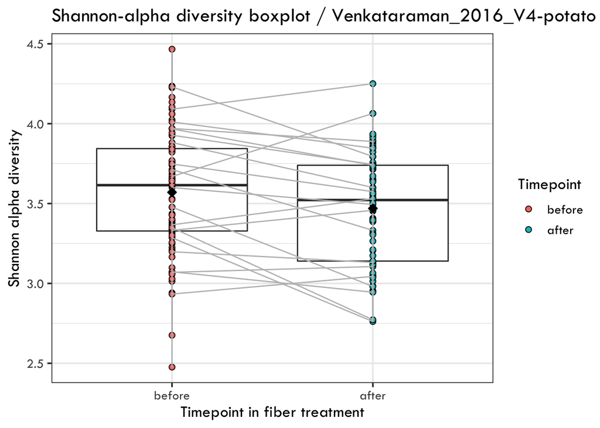

```r
ggplot (merged_alpha, aes(x= factor (timepoint, level= c("before","after")), y=Shannon)) +
  geom_boxplot() +
  geom_point(shape=21, size=2, (aes(fill = timepoint))) +
  scale_fill_hue(limits = c ("before","after")) +
  geom_line(aes(group = `subject_id`), color="grey") +
  labs(title = "Shannon-alpha diversity boxplot / Venkataraman_2016_V4-potato", x= "Timepoint in fiber treatment", y= "Shannon alpha diversity", fill="Timepoint") +
  theme_bw (base_family = "Tw Cen MT", base_size = 14) +
  stat_summary(fun = mean, geom = "point", shape=23, size=2.5, fill="black")
```

#### Save figure:

```r
ggsave("Figures/shannon_box.ALL.png", width = 7, height = 5)
```

##### Calculate means of both timepoints of Shannon with aggregate program https://r-coder.com/aggregate-r/ :

```r
means.shannon <- aggregate(merged_alpha$Shannon, list(merged_alpha$timepoint), mean)
means.shannon
```

```
#>   Group.1        x
#> 1   after 3.469546
#> 2  before 3.570385
```

#### Visualization Simpson by all timepoints:

##### Create a boxplot - Simpson:

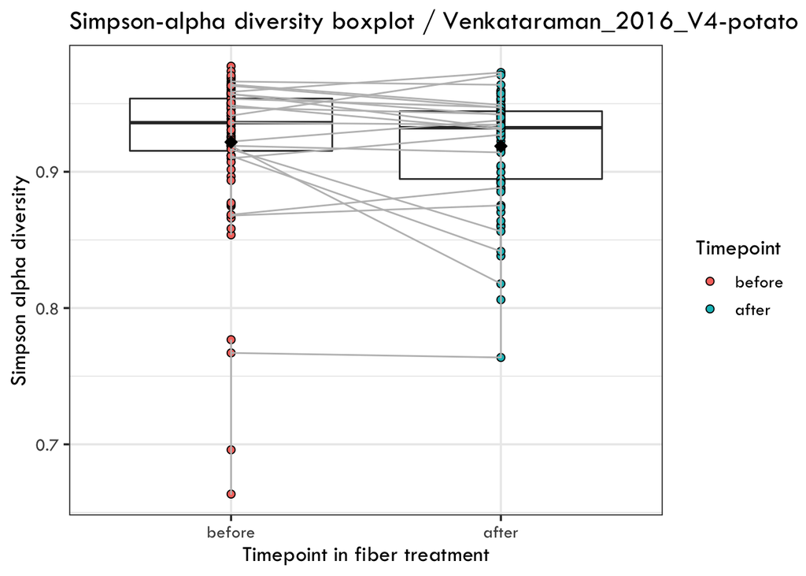

```r
ggplot (merged_alpha, aes(x= factor (timepoint, level= c("before","after")), y=Simpson)) +
  geom_boxplot() +
  geom_point(shape=21, size=2, (aes(fill = timepoint))) +
  scale_fill_hue(limits = c ("before","after")) +
  geom_line(aes(group = `subject_id`), color="grey") +
  labs(title = "Simpson-alpha diversity boxplot / Venkataraman_2016_V4-potato", x= "Timepoint in fiber treatment", y= "Simpson alpha diversity", fill="Timepoint") +
  theme_bw (base_family = "Tw Cen MT", base_size = 14) +
  stat_summary(fun = mean, geom = "point", shape=23, size=2.5, fill="black")
```

#### Save figure:

```r
ggsave("Figures/simpson_box.ALL.png", width = 7, height = 5)
```

##### Calculate means of both timepoints of Simpson with aggregate program https://r-coder.com/aggregate-r/ :

```r
means.simpson <- aggregate(merged_alpha$Simpson, list(merged_alpha$timepoint), mean)
means.simpson
```

```
#>   Group.1         x
#> 1   after 0.9187929
#> 2  before 0.9217543
```

#### Visualization Shannon by 2 timepoints only:

##### Subset data for only one timepoint for before and one timepoint for after fiber treatment, so that we can run paired-T-test:

```r
merged_alpha_2 <- merged_alpha [ which(merged_alpha$timepoint_id=='before_1' | merged_alpha$timepoint_id=='after_8'),]
```

#### Save subsetted merged alpha metrics and metadata in a text file:

```r
setwd("/Volumes/Seagate/Meta_analysis/Alpha_Beta_analysis/Venkataraman_2016_V4/Potato/Output_files")

write.table(x = merged_alpha_2, file = "5.subsetted_potato_alpha_metrics_merged_metadata.txt", sep = "\t", row.names = TRUE, col.names = NA)

#Take a look at the first few rows of the merged dataset:
head(merged_alpha_2)
```

```
#>      SampleID Richness  Shannon   Simpson                sampleid        study
#> 1  SRR3053238      180 4.165266 0.9682320 SRR3053238_venkataraman venkataraman
#> 8  SRR3053245      157 3.926594 0.9577721 SRR3053245_venkataraman venkataraman
#> 9  SRR3053246      151 3.740186 0.9461952 SRR3053246_venkataraman venkataraman
#> 16 SRR3053253      151 3.822629 0.9559535 SRR3053253_venkataraman venkataraman
#> 17 SRR3053254      127 3.435733 0.9336765 SRR3053254_venkataraman venkataraman
#> 24 SRR3053261      110 3.408212 0.9260795 SRR3053261_venkataraman venkataraman
#>           subject_id treatment timepoint timepoint_numeric timepoint_id
#> 1  venkataraman_U001     fiber    before                 1     before_1
#> 8  venkataraman_U001     fiber     after                 8      after_8
#> 9  venkataraman_U004     fiber    before                 1     before_1
#> 16 venkataraman_U004     fiber     after                 8      after_8
#> 17 venkataraman_U005     fiber    before                 1     before_1
#> 24 venkataraman_U005     fiber     after                 8      after_8
#>           sample_name1    fiber_type fiber_amount time_days number gender age
#> 1  venkataraman_U001_1 potato_starch          48g        1d      1     NA  NA
#> 8  venkataraman_U001_8 potato_starch          48g       17d      8     NA  NA
#> 9  venkataraman_U004_1 potato_starch          48g        1d      9     NA  NA
#> 16 venkataraman_U004_8 potato_starch          48g       17d     16     NA  NA
#> 17 venkataraman_U005_1 potato_starch          48g        1d     17     NA  NA
#> 24 venkataraman_U005_8 potato_starch          48g       17d     24     NA  NA
#>    sample-name-original subject_id2
#> 1                U001_1        U001
#> 8                U001_8        U001
#> 9                U004_1        U004
#> 16               U004_8        U004
#> 17               U005_1        U005
#> 24               U005_8        U005
```

##### Create a boxplot - Shannon for only before and after fiber treatment:

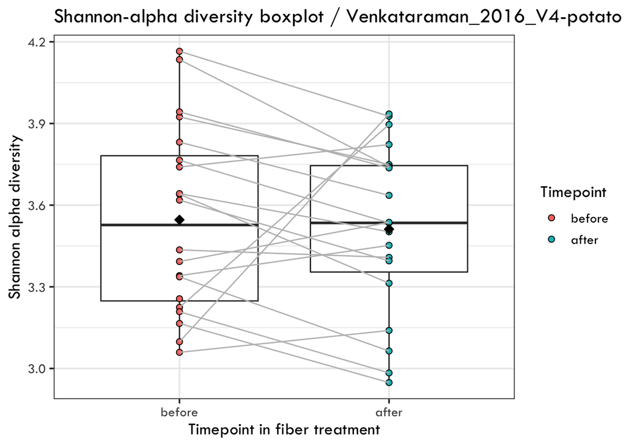

```r
ggplot (merged_alpha_2, aes(x= factor (timepoint, level= c("before","after")), y=Shannon)) +
  geom_boxplot() +
  geom_point(shape=21, size=2, (aes(fill = timepoint))) +
  scale_fill_hue(limits = c ( "before","after")) +
  geom_line(aes(group = `subject_id`), color="grey") +
  labs(title = "Shannon-alpha diversity boxplot / Venkataraman_2016_V4-potato", x= "Timepoint in fiber treatment", y= "Shannon alpha diversity", fill="Timepoint") +
  theme_bw (base_family = "Tw Cen MT", base_size = 14) +
  stat_summary(fun = mean, geom = "point", shape=23, size=2.5, fill="black")
```

#### Save figure:

```r
ggsave("Figures/shannon_box.2timepoints.png", width = 7, height = 5)
```

##### Calculate means of both timepoints of Shannon with aggregate program https://r-coder.com/aggregate-r/ :

```r
means.shannon_2 <- aggregate(merged_alpha_2$Shannon, list(merged_alpha_2$timepoint), mean)
means.shannon_2
```

```
#>   Group.1        x
#> 1   after 3.511707
#> 2  before 3.546136
```

##### Create a boxplot - Simpson for only before and after fiber treatment:

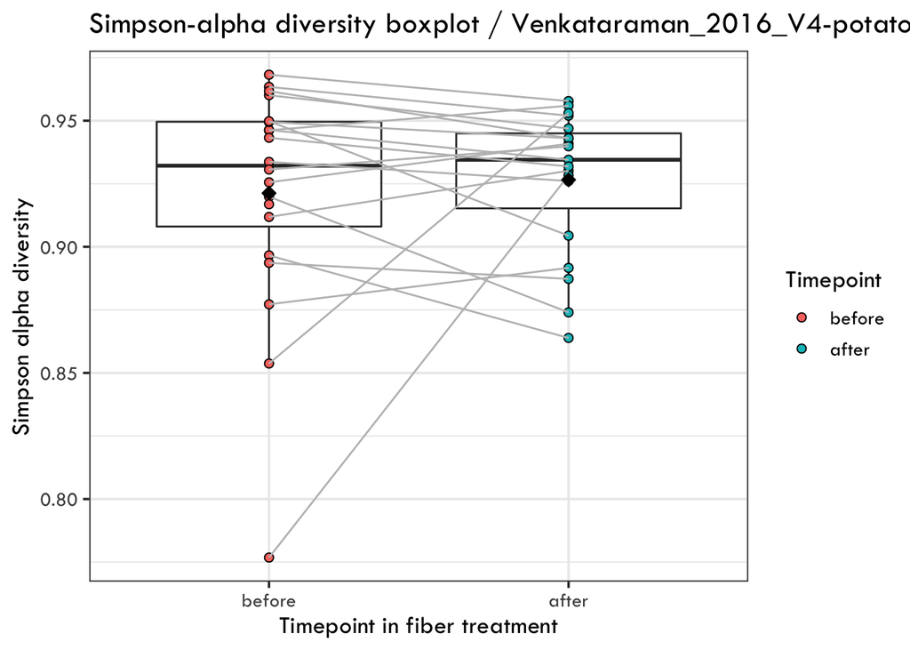

```r
ggplot (merged_alpha_2, aes(x= factor (timepoint, level= c("before","after")), y=Simpson)) +
  geom_boxplot() +
  geom_point(shape=21, size=2, (aes(fill = timepoint))) +
  scale_fill_hue(limits = c ("before","after")) +
  geom_line(aes(group = `subject_id`), color="grey") +
  labs(title = "Simpson-alpha diversity boxplot / Venkataraman_2016_V4-potato", x= "Timepoint in fiber treatment", y= "Simpson alpha diversity", fill="Timepoint") +
  theme_bw (base_family = "Tw Cen MT", base_size = 14) +
  stat_summary(fun = mean, geom = "point", shape=23, size=2.5, fill="black")
```

#### Save figure:

```r
ggsave("Figures/simpson_box.2timepoints.png", width = 7, height = 5)
```

```r
means.simpson_2 <- aggregate(merged_alpha_2$Simpson, list(merged_alpha_2$timepoint), mean)
means.simpson_2
```

```
#>   Group.1         x
#> 1   after 0.9265588
#> 2  before 0.9212495
```

##### Prepare dataframe to correct formatting for statistical testing:

```r
# Delete samples that do not have two timepoints:
pairs.only.all.alpha <- merged_alpha_2 %>%
  filter(duplicated(`subject_id`) | duplicated(`subject_id`, fromLast=TRUE)) %>%
  arrange(`timepoint`,`subject_id`)


#Save file with only before and during subjects, any subjects that did not have all timepoints were deleted:
write.table(x = pairs.only.all.alpha, file = "Output_files/6.potato_alpha_metrics_merged_metadata_only_pairs.txt", sep = "\t", row.names = TRUE, col.names = NA)


#Sort the data by timepoint and subject-id:
paired_data_alpha <- pairs.only.all.alpha[order(pairs.only.all.alpha$subject_id, pairs.only.all.alpha$`timepoint`),]

#see sorted data:
head(paired_data_alpha)
```

```
#>      SampleID Richness  Shannon   Simpson                sampleid        study
#> 1  SRR3053245      157 3.926594 0.9577721 SRR3053245_venkataraman venkataraman
#> 20 SRR3053238      180 4.165266 0.9682320 SRR3053238_venkataraman venkataraman
#> 2  SRR3053253      151 3.822629 0.9559535 SRR3053253_venkataraman venkataraman
#> 21 SRR3053246      151 3.740186 0.9461952 SRR3053246_venkataraman venkataraman
#> 3  SRR3053261      110 3.408212 0.9260795 SRR3053261_venkataraman venkataraman
#> 22 SRR3053254      127 3.435733 0.9336765 SRR3053254_venkataraman venkataraman
#>           subject_id treatment timepoint timepoint_numeric timepoint_id
#> 1  venkataraman_U001     fiber     after                 8      after_8
#> 20 venkataraman_U001     fiber    before                 1     before_1
#> 2  venkataraman_U004     fiber     after                 8      after_8
#> 21 venkataraman_U004     fiber    before                 1     before_1
#> 3  venkataraman_U005     fiber     after                 8      after_8
#> 22 venkataraman_U005     fiber    before                 1     before_1
#>           sample_name1    fiber_type fiber_amount time_days number gender age
#> 1  venkataraman_U001_8 potato_starch          48g       17d      8     NA  NA
#> 20 venkataraman_U001_1 potato_starch          48g        1d      1     NA  NA
#> 2  venkataraman_U004_8 potato_starch          48g       17d     16     NA  NA
#> 21 venkataraman_U004_1 potato_starch          48g        1d      9     NA  NA
#> 3  venkataraman_U005_8 potato_starch          48g       17d     24     NA  NA
#> 22 venkataraman_U005_1 potato_starch          48g        1d     17     NA  NA
#>    sample-name-original subject_id2
#> 1                U001_8        U001
#> 20               U001_1        U001
#> 2                U004_8        U004
#> 21               U004_1        U004
#> 3                U005_8        U005
#> 22               U005_1        U005
```

##### Perform summary and statistics to compare alpha diversity metrics between the same subjects before and after fiber intervention:

```r
#Do summary of Shannon alpha metric:
summary(paired_data_alpha$timepoint)
```

```
#>  after before
#>     19     19
```

```r
summary(paired_data_alpha$`subject_id`~timepoint~Shannon)
```

```
#>  Length   Class    Mode
#>       3 formula    call
```

```r
#pairwise t-test Shannon:
pairwise_t_test_shannon<- t.test(Shannon~timepoint,paired=TRUE, data=paired_data_alpha, p.adjust.method = "bonferroni" )
pairwise_t_test_shannon
```

```
#>
#>  Paired t-test
#>
#> data:  Shannon by timepoint
#> t = -0.67116, df = 18, p-value = 0.5106
#> alternative hypothesis: true difference in means is not equal to 0
#> 95 percent confidence interval:
#>  -0.2052608  0.1058677
#> sample estimates:
#> mean of the differences
#>             -0.04969655
```

```r
#pairwise t-test Simpson:
summary(paired_data_alpha$`subject_id`~timepoint~Simpson)
```

```
#>  Length   Class    Mode
#>       3 formula    call
```

```r
pairwise_t_test_simpson<- t.test(Simpson~timepoint,paired=TRUE, data=paired_data_alpha, p.adjust.method = "bonferroni" )
pairwise_t_test_simpson
```

```
#>
#>  Paired t-test
#>
#> data:  Simpson by timepoint
#> t = 0.47142, df = 18, p-value = 0.643
#> alternative hypothesis: true difference in means is not equal to 0
#> 95 percent confidence interval:
#>  -0.01755542  0.02771323
#> sample estimates:
#> mean of the differences
#>             0.005078903
```

```r
#general linear model:
glm.test.shannon <- glm(Shannon~timepoint, data=paired_data_alpha, family = "gaussian")
glm.test.shannon
```

```
#>
#> Call:  glm(formula = Shannon ~ timepoint, family = "gaussian", data = paired_data_alpha)
#>
#> Coefficients:
#>     (Intercept)  timepointbefore
#>          3.5117           0.0497
#>
#> Degrees of Freedom: 37 Total (i.e. Null);  36 Residual
#> Null Deviance:       3.935
#> Residual Deviance: 3.911     AIC: 27.44
```

```r
#linear mixed model: https://ourcodingclub.github.io/tutorials/mixed-models/
#association between timepoint and the Shannon, we want to know if that association exists after controlling for the variation in subjetc_id.
library(lme4)
lm.test.shannon <- lmer(Shannon~timepoint + (1|`subject_id`), data = paired_data_alpha)
summary(lm.test.shannon)
```

```
#> Linear mixed model fit by REML ['lmerMod']
#> Formula: Shannon ~ timepoint + (1 | subject_id)
#>    Data: paired_data_alpha
#>
#> REML criterion at convergence: 22.5
#>
#> Scaled residuals:
#>      Min       1Q   Median       3Q      Max
#> -1.96952 -0.39509 -0.01179  0.47813  1.91437
#>
#> Random effects:
#>  Groups     Name        Variance Std.Dev.
#>  subject_id (Intercept) 0.05657  0.2378
#>  Residual               0.05209  0.2282
#> Number of obs: 38, groups:  subject_id, 19
#>
#> Fixed effects:
#>                 Estimate Std. Error t value
#> (Intercept)      3.51171    0.07562  46.438
#> timepointbefore  0.04970    0.07405   0.671
#>
#> Correlation of Fixed Effects:
#>             (Intr)
#> timepontbfr -0.490
```

##### Looking at these plots and t-tests, there are a number of questions we want to ask: PENDING RESULTS

- Are before fiber samples more/less diverse than after fiber samples?
  - ANSWER: Based on the plots, it seems that alpha diversity slightly decreases
- Does diversity change after treatments?
  - ANSWER: Based on the mean alpha diversity metrics, it seems that after the intervention the diversity slighty decreases.
- Is the difference in microbiome richness between before and after fiber treatment statistically significant??
  - ANSWER: No, based on the paired t-tests for Shannon and Simpson alpha diversity metrics.

## _____________ Beta-Diversity Analysis________

DO NOT use rarefied data here because you can rarefy within the Bray-Curtis calculation:

#### Create your Bray-Curtis dissimilarities to use in NMDS ordination:

- Note: sample = is your rarefaction depth, which we are setting as the lowest reads in our dataset https://rdrr.io/cran/vegan/man/avgdist.html
- Default is Bray-Curtis calculated by vegdist()
- Transform data using square root to minimize influence of most abundant groups.
- avgdist=Averaged Subsampled Dissimilarity Matrices.The function computes the dissimilarity matrix of a dataset multiple times using vegdist while randomly subsampling the dataset each time. All of the subsampled iterations are then averaged (mean or median) to provide a distance matrix that represents the average of multiple subsampling iterations. We use median so as to discount any outlier subsamplings. https://cran.r-project.org/web/packages/vegan/vegan.pdf

```r
set.seed(2022) #reproducible results

bray.dist <- avgdist(SV.table,
                     sample = 2167,
                     meanfun = median, transf = sqrt, iterations = 1000)
```

#### Next, run an NMDS, which is a form of ordination and can be used to visualize beta diversity in base R:

```r
set.seed(2022) #reproducible results
NMDS1 <- metaMDS(bray.dist, autotransform = FALSE, k = 2)
```

```
#> *** No convergence -- monoMDS stopping criteria:
#>      1: no. of iterations >= maxit
#>     19: stress ratio > sratmax
```

```r
NMDS1
```

```
#>
#> Call:
#> metaMDS(comm = bray.dist, k = 2, autotransform = FALSE)
#>
#> global Multidimensional Scaling using monoMDS
#>
#> Data:     bray.dist
#> Distance: avgdist
#>
#> Dimensions: 2
#> Stress:     0.223426
#> Stress type 1, weak ties
#> No convergent solutions - best solution after 20 tries
#> Scaling: centring, PC rotation
#> Species: scores missing
```

##### Store the first two columns as the x and y coordinates, so that they may be plotted:

```r
coordinates <- data.frame(NMDS1$points[,1:2])

#Save Bray-Curtis dissimilarity NMDS cordinates:
  write.table(x = coordinates, file = "Output_files/7.NMDS.coordinates.txt", sep = "\t", row.names = TRUE, col.names = NA)
```

##### Plot the coordinates data from NMDS with base R:

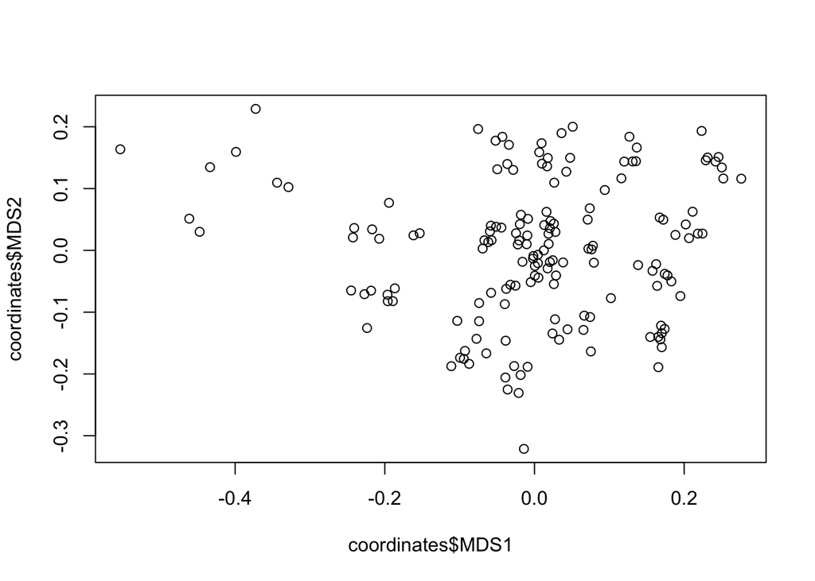

```r
plot(x = coordinates$MDS1, y = coordinates$MDS2)
```

##### To make a more sophisticated plot, merge the stress scores with the metadata file:

```r
nmds_plus_metadata <- merge(coordinates, metadata, by.x = "row.names", by.y = "sample_id_2")

#Save Bray-Curtis dissimilarity NMDS cordinates plus metadata:
  write.table(x = coordinates, file = "Output_files/8.NMDS.coordinates.metadata.txt", sep = "\t", row.names = TRUE, col.names = NA)
```

#### Build NMDS with timepoint as color:

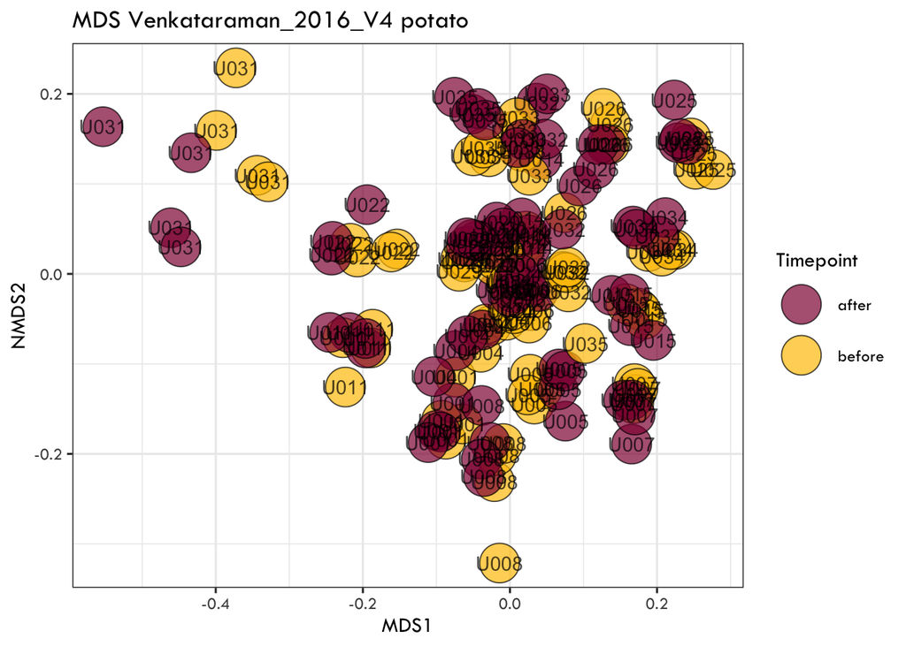

```r
  ggplot(data = nmds_plus_metadata) +
  aes(x = MDS1, y = MDS2, fill = as.factor(`timepoint`)) +
  geom_point(pch = 21, aes(fill = as.factor(`timepoint`)), size = 10, alpha = 0.7) +
  scale_fill_manual(values =c("#900C3F", "#FFC300")) +
  guides(color = F, fill = guide_legend(override.aes = list(shape = 21))) +
  geom_text(label = (nmds_plus_metadata$`subject_id2`), alpha = 0.7) +
labs(title = "MDS Venkataraman_2016_V4 potato", x= "MDS1", y= "NMDS2", fill="Timepoint") +
  theme_bw (base_family = "Tw Cen MT", base_size = 12)
```

#### Save figure:

```r
ggsave("Figures/NMDS.all.png", width = 7, height = 5)
```

#### To run statistical analyses, make averaged Bray-Curtis dissimilarity matrix:

```r
set.seed(2022) #reproducible results
  bray.dist.matrix <- as.data.frame(as.matrix(avgdist(SV.table, sample = 2167, meanfun = median, transf = sqrt, iterations = 1000))) #default is Bray-Curtis calculated by vegdist()
```

#### Save Bray-Curtis dissimilarity matrix in a file:

```r
  write.table(x = bray.dist.matrix, file = "Output_files/9.potato_median_bray_curtis_sqrt_q1_single_rarefied_to_2167.txt", sep = "\t", row.names = TRUE, col.names = NA)
```

#### Confirm variables have been changed to factors in metadata file (if you have not done so already):

```r
class(metadata$`timepoint`)
```

```
#> [1] "factor"
```

```r
class(metadata$`subject_id`)
```

```
#> [1] "factor"
```

#### Example 1,interaction subject X timepoint, by=terms assesses the significance for each term sequentially from first to last:

```r
set.seed(2022) #reproducible results
  PERMANOVA1 <- adonis2(bray.dist.matrix~`subject_id`*`timepoint`, data=metadata, method = "bray", by="terms",permutations = 999)
  PERMANOVA1
```

```
#> Permutation test for adonis under reduced model
#> Terms added sequentially (first to last)
#> Permutation: free
#> Number of permutations: 999
#>
#> adonis2(formula = bray.dist.matrix ~ subject_id * timepoint, data = metadata, permutations = 999, method = "bray", by = "terms")
#>                       Df SumOfSqs      R2       F Pr(>F)
#> subject_id            19  26.4015 0.84084 47.8204  0.001 ***
#> timepoint              1   0.2826 0.00900  9.7264  0.001 ***
#> subject_id:timepoint  19   1.3152 0.04189  2.3822  0.001 ***
#> Residual             117   3.3997 0.10828
#> Total                156  31.3990 1.00000
#> ---
#> Signif. codes:  0 '***' 0.001 '**' 0.01 '*' 0.05 '.' 0.1 ' ' 1
```

```r
  #Save PERMANOVA:
write.table(PERMANOVA1, file = "Output_files/10.PERMANOVA_interaction_term.txt", sep = "\t", row.names = TRUE, col.names = NA)
```

#### Example 2, testing interaction subject X timepoint, ignoring order by=NULL assesses the overall significance of all terms together:

```r
set.seed(2022) #reproducible results
 PERMANOVA2 <- adonis2(bray.dist.matrix~`subject_id`*`timepoint`, data=metadata, method = "bray", by= NULL, permutations = 999)

  PERMANOVA2
```

```
#> Permutation test for adonis under reduced model
#> Permutation: free
#> Number of permutations: 999
#>
#> adonis2(formula = bray.dist.matrix ~ subject_id * timepoint, data = metadata, permutations = 999, method = "bray", by = NULL)
#>           Df SumOfSqs      R2      F Pr(>F)
#> Model     39  27.9993 0.89172 24.707  0.001 ***
#> Residual 117   3.3997 0.10828
#> Total    156  31.3990 1.00000
#> ---
#> Signif. codes:  0 '***' 0.001 '**' 0.01 '*' 0.05 '.' 0.1 ' ' 1
```

```r
  #Save PERMANOVA:
write.table(PERMANOVA2, file = "Output_files/11.PERMANOVA_interaction_null.txt", sep = "\t", row.names = TRUE, col.names = NA)
```

#### Example 3, not testing interaction subject + timepoint, by=terms assesses the significance for each term sequentially from first to last::

```r
set.seed(2022) #reproducible results
PERMANOVA3 <-  adonis2(bray.dist.matrix~`subject_id`+`timepoint`, data=metadata, method = "bray", by="terms",permutations = 999)

  PERMANOVA3
```

```
#> Permutation test for adonis under reduced model
#> Terms added sequentially (first to last)
#> Permutation: free
#> Number of permutations: 999
#>
#> adonis2(formula = bray.dist.matrix ~ subject_id + timepoint, data = metadata, permutations = 999, method = "bray", by = "terms")
#>             Df SumOfSqs      R2       F Pr(>F)
#> subject_id  19  26.4015 0.84084 40.0808  0.001 ***
#> timepoint    1   0.2826 0.00900  8.1522  0.001 ***
#> Residual   136   4.7149 0.15016
#> Total      156  31.3990 1.00000
#> ---
#> Signif. codes:  0 '***' 0.001 '**' 0.01 '*' 0.05 '.' 0.1 ' ' 1
```

```r
  #Save PERMANOVA:
write.table(PERMANOVA3, file = "Output_files/12.PERMANOVA_NOinteraction_term.txt", sep = "\t", row.names = TRUE, col.names = NA)
```

#### Example 4, not testing interaction subject + timepoint, ignoring order by=NULL assesses the overall significance of all terms together:

```r
set.seed(2022) #reproducible results
PERMANOVA4 <-  adonis2(bray.dist.matrix~`subject_id`+`timepoint`, data=metadata, method = "bray", by=NULL,permutations = 999)

  PERMANOVA4
```

```
#> Permutation test for adonis under reduced model
#> Permutation: free
#> Number of permutations: 999
#>
#> adonis2(formula = bray.dist.matrix ~ subject_id + timepoint, data = metadata, permutations = 999, method = "bray", by = NULL)
#>           Df SumOfSqs      R2      F Pr(>F)
#> Model     20  26.6841 0.84984 38.484  0.001 ***
#> Residual 136   4.7149 0.15016
#> Total    156  31.3990 1.00000
#> ---
#> Signif. codes:  0 '***' 0.001 '**' 0.01 '*' 0.05 '.' 0.1 ' ' 1
```

```r
  #Save PERMANOVA:
write.table(PERMANOVA4, file = "Output_files/13.PERMANOVA_NOinteraction_null.txt", sep = "\t", row.names = TRUE, col.names = NA)
```

#### Example 5, testing subject_id by itself:

```r
set.seed(2022) #reproducible results
  adonis2(bray.dist.matrix~`subject_id`, data=metadata, permutations = 999, method = "bray")
```

```
#> Permutation test for adonis under reduced model
#> Terms added sequentially (first to last)
#> Permutation: free
#> Number of permutations: 999
#>
#> adonis2(formula = bray.dist.matrix ~ subject_id, data = metadata, permutations = 999, method = "bray")
#>             Df SumOfSqs      R2      F Pr(>F)
#> subject_id  19  26.4015 0.84084 38.092  0.001 ***
#> Residual   137   4.9976 0.15916
#> Total      156  31.3990 1.00000
#> ---
#> Signif. codes:  0 '***' 0.001 '**' 0.01 '*' 0.05 '.' 0.1 ' ' 1
```

- subject_id = YES significant, explaining 84% of variance
- timepoint (before vs after) = YES significant, explaining 0.9% of variance
- subject_id and timepoint interaction = YES significant, explaining 4.2% of variance